# R Notebook

```r
library(broom)
```

```r
diamonds <- read_csv("data/diamonds.csv")
diamonds <- diamonds %>%
  select(-X1)

View(diamonds)

glimpse(diamonds)
```

```
Rows: 53,940
Columns: 10
$ carat   <dbl> 0.23, 0.21, 0.23, 0.29, 0.31, 0.24, 0.24, 0.26, 0.22, 0.23, 0…
$ cut     <chr> "Ideal", "Premium", "Good", "Premium", "Good", "Very Good", "…
$ color   <chr> "E", "E", "E", "I", "J", "J", "I", "H", "E", "H", "J", "J", "…
$ clarity <chr> "SI2", "SI1", "VS1", "VS2", "SI2", "VVS2", "VVS1", "SI1", "VS…
$ depth   <dbl> 61.5, 59.8, 56.9, 62.4, 63.3, 62.8, 62.3, 61.9, 65.1, 59.4, 6…
$ table   <dbl> 55, 61, 65, 58, 58, 57, 57, 55, 61, 61, 55, 56, 61, 54, 62, 5…
$ price   <dbl> 326, 326, 327, 334, 335, 336, 336, 337, 337, 338, 339, 340, 3…
$ x       <dbl> 3.95, 3.89, 4.05, 4.20, 4.34, 3.94, 3.95, 4.07, 3.87, 4.00, 4…
$ y       <dbl> 3.98, 3.84, 4.07, 4.23, 4.35, 3.96, 3.98, 4.11, 3.78, 4.05, 4…
$ z       <dbl> 2.43, 2.31, 2.31, 2.63, 2.75, 2.48, 2.47, 2.53, 2.49, 2.39, 2…
```

```r
summary(diamonds)
```

```
     carat            cut               color             clarity
 Min.   :0.2000   Length:53940       Length:53940       Length:53940
 1st Qu.:0.4000   Class :character   Class :character   Class :character
 Median :0.7000   Mode  :character   Mode  :character   Mode  :character
 Mean   :0.7979
 3rd Qu.:1.0400
 Max.   :5.0100
     depth           table           price             x
 Min.   :43.00   Min.   :43.00   Min.   :  326   Min.   : 0.000
 1st Qu.:61.00   1st Qu.:56.00   1st Qu.:  950   1st Qu.: 4.710
 Median :61.80   Median :57.00   Median : 2401   Median : 5.700
 Mean   :61.75   Mean   :57.46   Mean   : 3933   Mean   : 5.731
 3rd Qu.:62.50   3rd Qu.:59.00   3rd Qu.: 5324   3rd Qu.: 6.540
 Max.   :79.00   Max.   :95.00   Max.   :18823   Max.   :10.740
       y                z
 Min.   : 0.000   Min.   : 0.000
 1st Qu.: 4.720   1st Qu.: 2.910
 Median : 5.710   Median : 3.530
 Mean   : 5.735   Mean   : 3.539
 3rd Qu.: 6.540   3rd Qu.: 4.040
 Max.   :58.900   Max.   :31.800
```

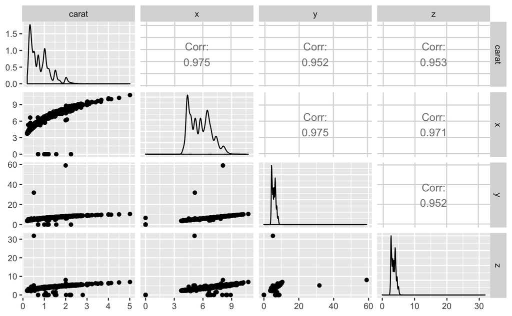

```r
#It isn't any NA in diamonds data set

diamonds %>%
  select(carat, x, y, z) %>%
  ggpairs()
```

The correlation between x to carat is 0.975, y to carat 0.952 and z to carat is 0.953. So it is a high correlation between the four variables.

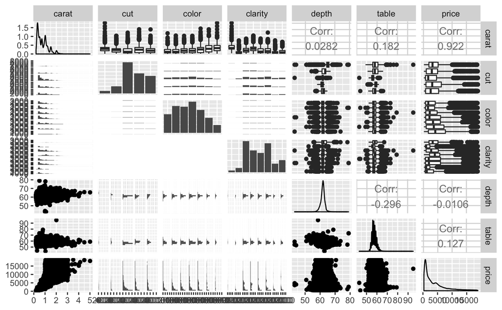

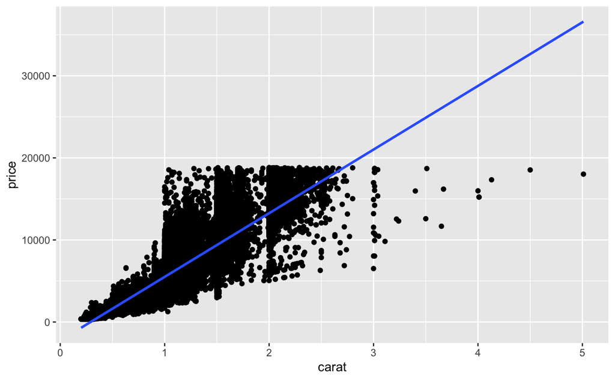

It is a very strong correlation between carat and price and a very small correlation (0.127) between proce and table.

```r
unique(diamonds_1$cut)
```

```
[1] "Ideal"     "Premium"   "Good"      "Very Good" "Fair"
```

```r
unique(diamonds_1$color)
```

```
[1] "E" "I" "J" "H" "F" "G" "D"
```

```r
unique(diamonds_1$clarity)
```

```
[1] "SI2"  "SI1"  "VS1"  "VS2"  "VVS2" "VVS1" "I1"   "IF"
```

```r
diamonds_1 <- diamonds_1 %>%
  dummy_cols(select_columns = c("cut", "color", "clarity"),
             remove_first_dummy = TRUE,
             remove_selected_columns = TRUE)
```

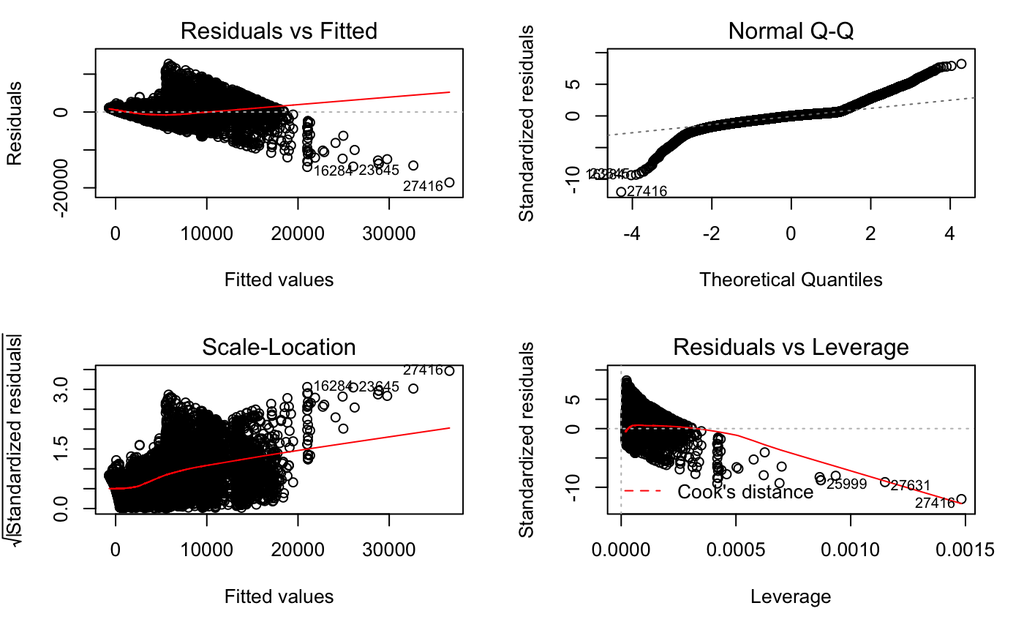

The Residual vs Fitted the the data don’t look very independent, after 20000 all of the points are locate under the line. The data doesn’t look very normal and in the scale location plote the line trend to go up after 10000, the cook line doesn’t show any particual oulier that could be important.

```r
summary(model_1)
```

```
Call:
lm(formula = price ~ carat, data = diamonds_1)

Residuals:
     Min       1Q   Median       3Q      Max
-18585.3   -804.8    -18.9    537.4  12731.7

Coefficients:
            Estimate Std. Error t value Pr(>|t|)
(Intercept) -2256.36      13.06  -172.8   <2e-16 ***
carat        7756.43      14.07   551.4   <2e-16 ***
---
Signif. codes:  0 ‘***’ 0.001 ‘**’ 0.01 ‘*’ 0.05 ‘.’ 0.1 ‘ ’ 1

Residual standard error: 1549 on 53938 degrees of freedom
Multiple R-squared:  0.8493,    Adjusted R-squared:  0.8493
F-statistic: 3.041e+05 on 1 and 53938 DF,  p-value: < 2.2e-16
```

The p values of carat is less that 0.05 that is razonable, (r squared = 0.8493) the 84.93% of the variation in price in the sample data can be explained by variation in carat. But I am not particulary convice that this is a linear regresion.

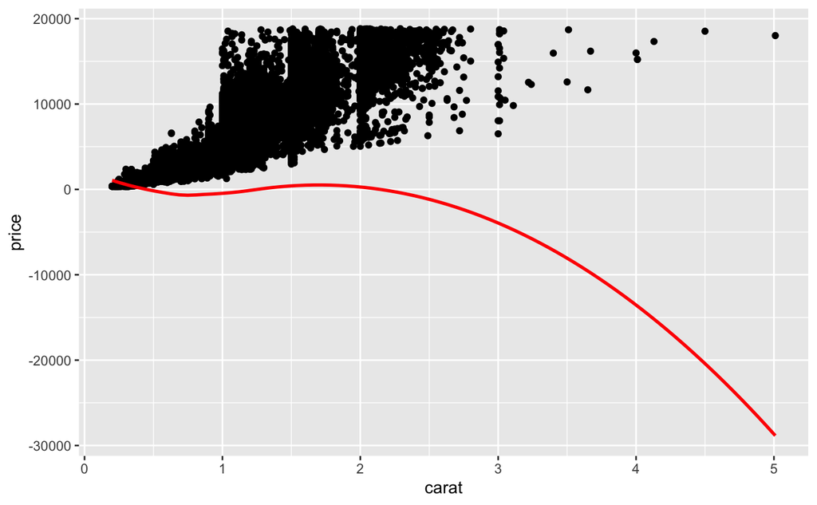

```r
diamonds_1 %>%
  add_residuals(model_1, var = "residual") %>%
  ggplot(aes(x = carat)) +
  geom_point(aes(y = price)) +
  geom_smooth(aes(y = residual), method = "loess", col = "red", se = FALSE)
```

```r
summary(model_log_x)
```

```
Call:
lm(formula = price ~ log(carat), data = diamonds_1)

Residuals:
    Min      1Q  Median      3Q     Max
-6137.4 -1495.1  -328.3  1141.9 12075.3

Coefficients:
            Estimate Std. Error t value Pr(>|t|)
(Intercept)  6237.84      10.73   581.2   <2e-16 ***
log(carat)   5836.02      15.21   383.8   <2e-16 ***
---
Signif. codes:  0 ‘***’ 0.001 ‘**’ 0.01 ‘*’ 0.05 ‘.’ 0.1 ‘ ’ 1

Residual standard error: 2066 on 53938 degrees of freedom
Multiple R-squared:  0.7319,    Adjusted R-squared:  0.7319
F-statistic: 1.473e+05 on 1 and 53938 DF,  p-value: < 2.2e-16
```

with log x r^2 decrease

```r
model_log_y <- lm(formula = log(price) ~ carat, data = diamonds_1)

summary(model_log_y)
```

```
Call:
lm(formula = log(price) ~ carat, data = diamonds_1)

Residuals:
    Min      1Q  Median      3Q     Max
-6.2844 -0.2449  0.0335  0.2578  1.5642

Coefficients:
            Estimate Std. Error t value Pr(>|t|)
(Intercept) 6.215021   0.003348    1856   <2e-16 ***
carat       1.969757   0.003608     546   <2e-16 ***
---
Signif. codes:  0 ‘***’ 0.001 ‘**’ 0.01 ‘*’ 0.05 ‘.’ 0.1 ‘ ’ 1

Residual standard error: 0.3972 on 53938 degrees of freedom
Multiple R-squared:  0.8468,    Adjusted R-squared:  0.8468
F-statistic: 2.981e+05 on 1 and 53938 DF,  p-value: < 2.2e-16
```

with log(y) r^2 is lower but only for few decimals

```r
summary(model_logx_logy)
```

```
Call:
lm(formula = log(price) ~ log(carat), data = diamonds_1)

Residuals:
     Min       1Q   Median       3Q      Max
-1.50833 -0.16951 -0.00591  0.16637  1.33793

Coefficients:
            Estimate Std. Error t value Pr(>|t|)
(Intercept) 8.448661   0.001365  6190.9   <2e-16 ***
log(carat)  1.675817   0.001934   866.6   <2e-16 ***
---
Signif. codes:  0 ‘***’ 0.001 ‘**’ 0.01 ‘*’ 0.05 ‘.’ 0.1 ‘ ’ 1

Residual standard error: 0.2627 on 53938 degrees of freedom
Multiple R-squared:  0.933, Adjusted R-squared:  0.933
F-statistic: 7.51e+05 on 1 and 53938 DF,  p-value: < 2.2e-16
```

with log x and y r^square increase, let’s check the graph

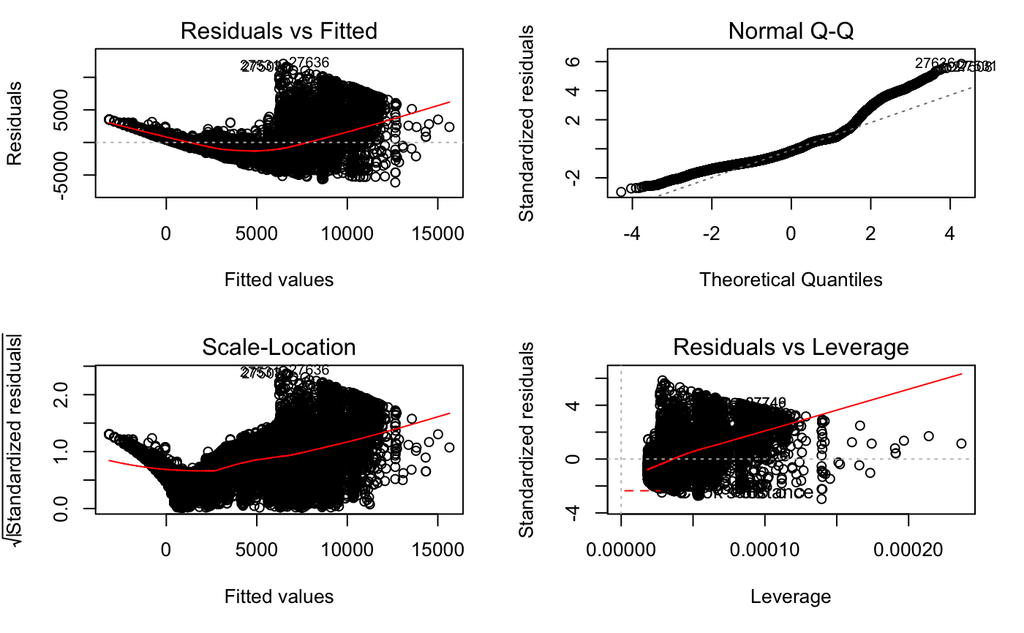

```r
par(mfrow = c(2, 2))
plot(model_log_x)
```

Special the normal plot is very afected for the change in x

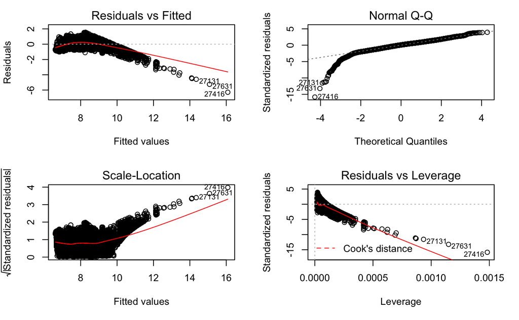

```r
par(mfrow = c(2, 2))
plot(model_log_y)
```

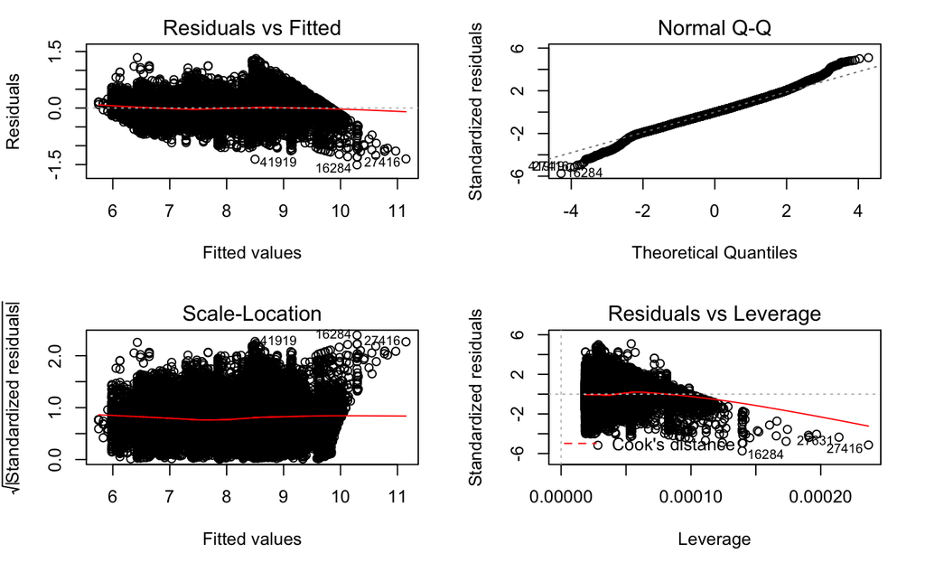

```r
par(mfrow = c(2, 2))
plot(model_logx_logy)
```

The scale location improve, don’t show any particular trend, the residual fitted improve but few points continue to be under after 10, and the data is more normal

```r
summary(model_log_cut)
```

```
Call:
lm(formula = log(price) ~ log(carat) + cut_good + cut_ideal +
    cut_premium + cut_very_good, data = diamonds_1)

Residuals:
     Min       1Q   Median       3Q      Max
-1.52247 -0.16484 -0.00587  0.16087  1.38115

Coefficients:
              Estimate Std. Error t value Pr(>|t|)
(Intercept)   8.200125   0.006343 1292.69   <2e-16 ***
log(carat)    1.695771   0.001910  887.68   <2e-16 ***
cut_good      0.163245   0.007324   22.29   <2e-16 ***
cut_ideal     0.317212   0.006632   47.83   <2e-16 ***
cut_premium   0.238217   0.006716   35.47   <2e-16 ***
cut_very_good 0.240753   0.006779   35.52   <2e-16 ***
---
Signif. codes:  0 ‘***’ 0.001 ‘**’ 0.01 ‘*’ 0.05 ‘.’ 0.1 ‘ ’ 1

Residual standard error: 0.2545 on 53934 degrees of freedom
Multiple R-squared:  0.9371,    Adjusted R-squared:  0.9371
F-statistic: 1.607e+05 on 5 and 53934 DF,  p-value: < 2.2e-16
```

only improve the log distribution by 0.4% point in RSquare and the standar error is lower

```r
model_log_color <- lm(formula = log(price) ~ log(carat) + color_e +
                     color_f + color_g + color_h + color_i + color_j,
                    data = diamonds_1 )

summary(model_log_color)
```

```
Call:
lm(formula = log(price) ~ log(carat) + color_e + color_f + color_g +
    color_h + color_i + color_j, data = diamonds_1)

Residuals:
     Min       1Q   Median       3Q      Max
-1.49987 -0.14888  0.00257  0.15316  1.27815

Coefficients:
             Estimate Std. Error  t value Pr(>|t|)
(Intercept)  8.572034   0.003051 2809.531  < 2e-16 ***
log(carat)   1.728631   0.001814  952.727  < 2e-16 ***
color_e     -0.025460   0.003748   -6.793 1.11e-11 ***
color_f     -0.034455   0.003773   -9.132  < 2e-16 ***
color_g     -0.055399   0.003653  -15.166  < 2e-16 ***
color_h     -0.189859   0.003917  -48.468  < 2e-16 ***
color_i     -0.286928   0.004383  -65.467  < 2e-16 ***
color_j     -0.425038   0.005417  -78.466  < 2e-16 ***
---
Signif. codes:  0 ‘***’ 0.001 ‘**’ 0.01 ‘*’ 0.05 ‘.’ 0.1 ‘ ’ 1

Residual standard error: 0.2372 on 53932 degrees of freedom
Multiple R-squared:  0.9454,    Adjusted R-squared:  0.9454
F-statistic: 1.333e+05 on 7 and 53932 DF,  p-value: < 2.2e-16
```

The r square is higher that with cut and the standar error is lower

```r
model_log_clarity <- lm(formula = log(price) ~ log(carat) + clarity_if +
                     clarity_si1 + clarity_si2 + clarity_vs1 + clarity_vs2 +
                      clarity_vvs1 + clarity_vvs2, data = diamonds_1 )

summary(model_log_clarity)
```

```
Call:
lm(formula = log(price) ~ log(carat) + clarity_if + clarity_si1 +
    clarity_si2 + clarity_vs1 + clarity_vs2 + clarity_vvs1 +
    clarity_vvs2, data = diamonds_1)

Residuals:
     Min       1Q   Median       3Q      Max
-0.97521 -0.12085  0.01048  0.12561  1.85854

Coefficients:
             Estimate Std. Error t value Pr(>|t|)
(Intercept)  7.768115   0.006940 1119.25   <2e-16 ***
log(carat)   1.806424   0.001514 1193.23   <2e-16 ***
clarity_if   1.114625   0.008376  133.07   <2e-16 ***
clarity_si1  0.624558   0.007163   87.19   <2e-16 ***
clarity_si2  0.479658   0.007217   66.46   <2e-16 ***
clarity_vs1  0.820461   0.007306  112.30   <2e-16 ***
clarity_vs2  0.775248   0.007197  107.72   <2e-16 ***
clarity_vvs1 1.028298   0.007745  132.77   <2e-16 ***
clarity_vvs2 0.979221   0.007529  130.05   <2e-16 ***
---
Signif. codes:  0 ‘***’ 0.001 ‘**’ 0.01 ‘*’ 0.05 ‘.’ 0.1 ‘ ’ 1

Residual standard error: 0.1888 on 53931 degrees of freedom
Multiple R-squared:  0.9654,    Adjusted R-squared:  0.9654
F-statistic: 1.879e+05 on 8 and 53931 DF,  p-value: < 2.2e-16
```

The Standar error is lower and the R^2 is higher by roughly 2%

```r
summary(model_log_clarity_i)
```

[output not shown]

[output cut: 967 more lines]

```
clarity_if:clarity_si1:clarity_si2:clarity_vs2:clarity_vvs2
log(carat):clarity_if:clarity_vs1:clarity_vs2:clarity_vvs2
log(carat):clarity_si1:clarity_vs1:clarity_vs2:clarity_vvs2
clarity_if:clarity_si1:clarity_vs1:clarity_vs2:clarity_vvs2
log(carat):clarity_si2:clarity_vs1:clarity_vs2:clarity_vvs2
clarity_if:clarity_si2:clarity_vs1:clarity_vs2:clarity_vvs2
clarity_si1:clarity_si2:clarity_vs1:clarity_vs2:clarity_vvs2
log(carat):clarity_if:clarity_si1:clarity_vvs1:clarity_vvs2
 [ reached getOption("max.print") -- omitted 56 rows ]
---
Signif. codes:  0 ‘***’ 0.001 ‘**’ 0.01 ‘*’ 0.05 ‘.’ 0.1 ‘ ’ 1

Residual standard error: 0.1877 on 53924 degrees of freedom
Multiple R-squared:  0.9658,    Adjusted R-squared:  0.9658
F-statistic: 1.014e+05 on 15 and 53924 DF,  p-value: < 2.2e-16
```

I don’t believe the interaction add any value the standar error and r quare are quite the same. For the graph I will only use the variable that I believe will influence more the change that is clarity_if

```r
model_log_clarity_if <- lm(formula = log(price) ~ log(carat) * clarity_if,
                           data = diamonds_1 )
```

[output not shown]